# EDA Project - Explore and Summarize Data - Red Wine Quality (v2)

Daniel

27 December 2017

### 1. Introduction

We start with obtaining a summary of the dataset:

```
##        X          fixed.acidity   volatile.acidity  citric.acid
##  Min.   :   1.0   Min.   : 4.60   Min.   :0.1200   Min.   :0.000
##  1st Qu.: 400.5   1st Qu.: 7.10   1st Qu.:0.3900   1st Qu.:0.090
##  Median : 800.0   Median : 7.90   Median :0.5200   Median :0.260
##  Mean   : 800.0   Mean   : 8.32   Mean   :0.5278   Mean   :0.271
##  3rd Qu.:1199.5   3rd Qu.: 9.20   3rd Qu.:0.6400   3rd Qu.:0.420
##  Max.   :1599.0   Max.   :15.90   Max.   :1.5800   Max.   :1.000
##  residual.sugar     chlorides       free.sulfur.dioxide
##  Min.   : 0.900   Min.   :0.01200   Min.   : 1.00
##  1st Qu.: 1.900   1st Qu.:0.07000   1st Qu.: 7.00
##  Median : 2.200   Median :0.07900   Median :14.00
##  Mean   : 2.539   Mean   :0.08747   Mean   :15.87
##  3rd Qu.: 2.600   3rd Qu.:0.09000   3rd Qu.:21.00
##  Max.   :15.500   Max.   :0.61100   Max.   :72.00
##  total.sulfur.dioxide    density             pH          sulphates
##  Min.   :  6.00       Min.   :0.9901   Min.   :2.740   Min.   :0.3300
##  1st Qu.: 22.00       1st Qu.:0.9956   1st Qu.:3.210   1st Qu.:0.5500
##  Median : 38.00       Median :0.9968   Median :3.310   Median :0.6200
##  Mean   : 46.47       Mean   :0.9967   Mean   :3.311   Mean   :0.6581
##  3rd Qu.: 62.00       3rd Qu.:0.9978   3rd Qu.:3.400   3rd Qu.:0.7300
##  Max.   :289.00       Max.   :1.0037   Max.   :4.010   Max.   :2.0000
##     alcohol         quality
##  Min.   : 8.40   Min.   :3.000
##  1st Qu.: 9.50   1st Qu.:5.000
##  Median :10.20   Median :6.000
##  Mean   :10.42   Mean   :5.636
##  3rd Qu.:11.10   3rd Qu.:6.000
##  Max.   :14.90   Max.   :8.000
```

Our dataset contains 13 variables, with 1599 observations.

#### 1.1 Wine Quality

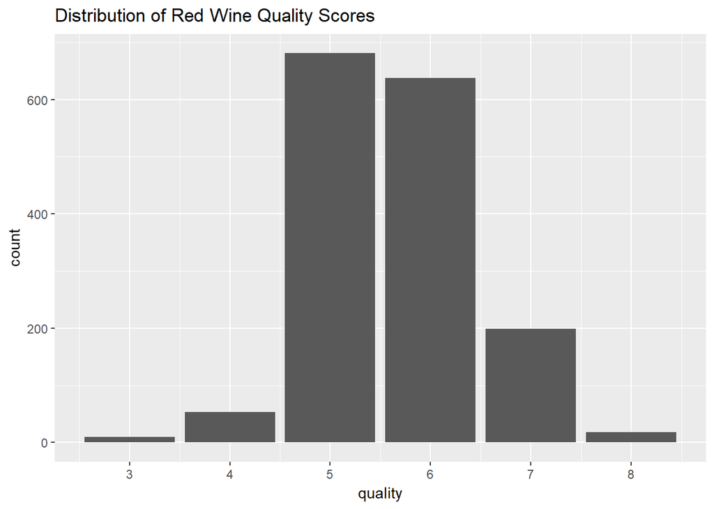

Observations:

1. The distribution is bimodal: Most wine are given a score of either 5 or 6.
2. This is an unbalanced dataset - the vast majority of observations are of wines with quality ratings 5 and 6. In particular, there are only 10 wines of very poor quality (rating 3) and only 18 wines of very good quality (rating 8). We will have to bear this in mind when trying to parse out relationships with quality and other variables in the dataset.

#### 1.2. Alcohol Content

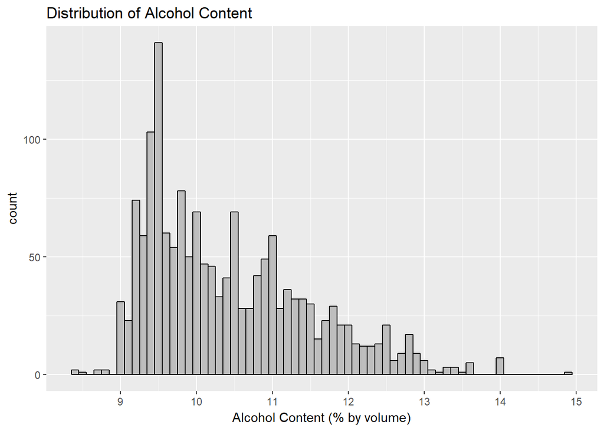

Observation: We notice that the distribution is skewed right. The mode of the observations occurs at 9.5% alcohol content. However, to get a clearer picture of the distribution and reduce the skew, it would help to scale the x axis using a log scale. I do that below:

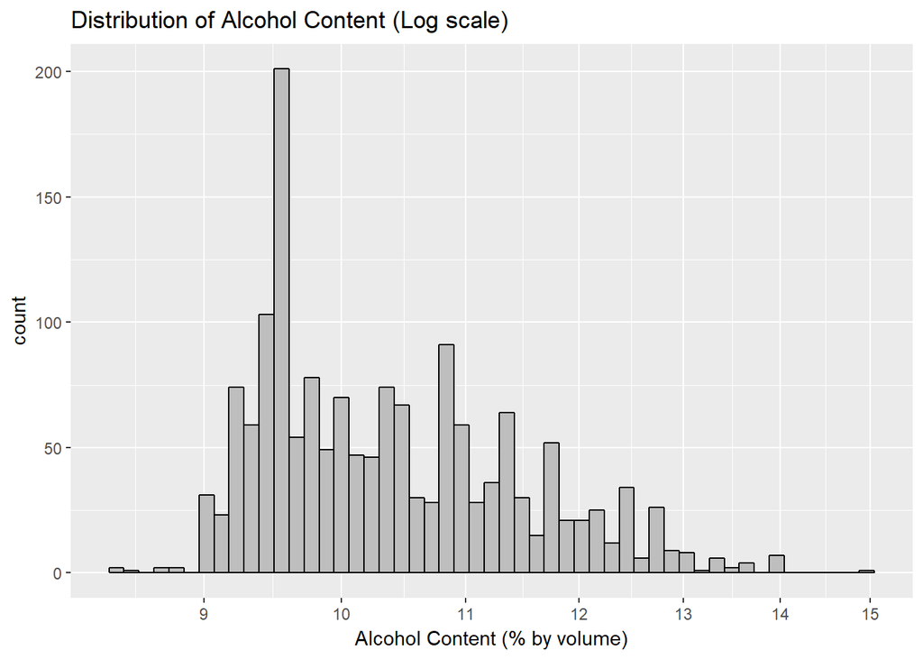

Observation: Scaling the x axis does not qualitatively change the shape of the distribution. In retrospect, the reason for this is that the range of the scale is limited, with most of the observations lying in the range of 9% - 13%. Hence, applying the log scale does not affect the gap between the values, and consequently the scale, much.

Fortunately, we can still compute the mean and median values using the summary function. We see that the mean is 10.42 and the median is 10.20. However, the non-normality of the distribution will make it less straightforward to use it in statistical inference.

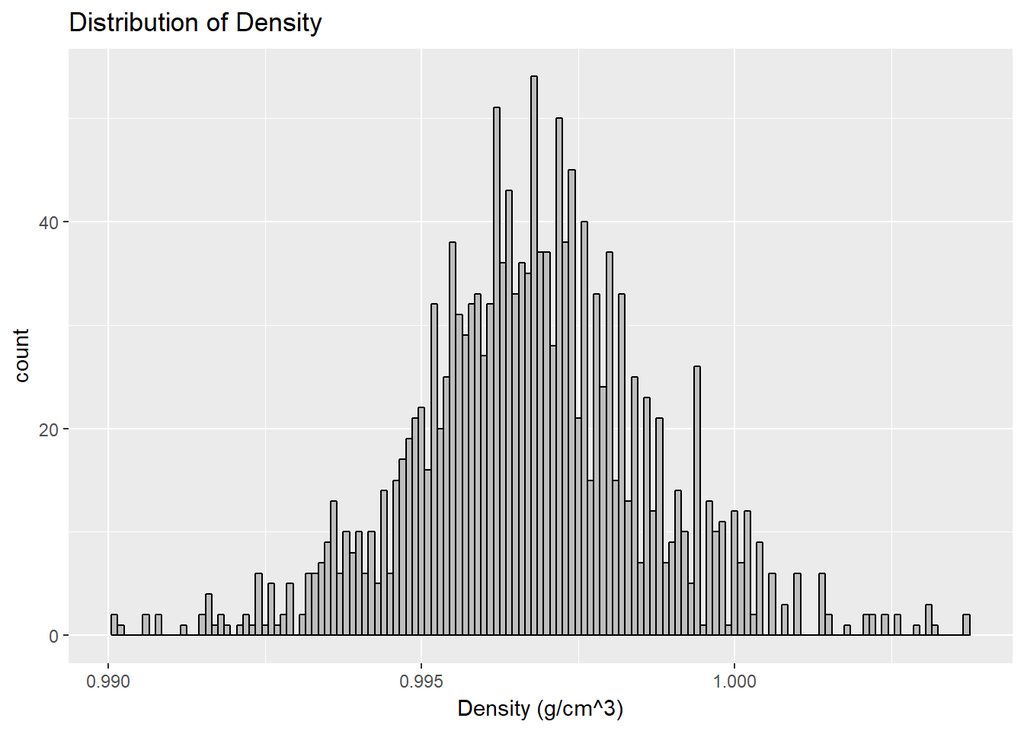

Observation: The distribution of density looks normal, with the mean/median/mode occuring somewhere in between 0.995 g/cm^3 and 0.9975 g/cm^3.

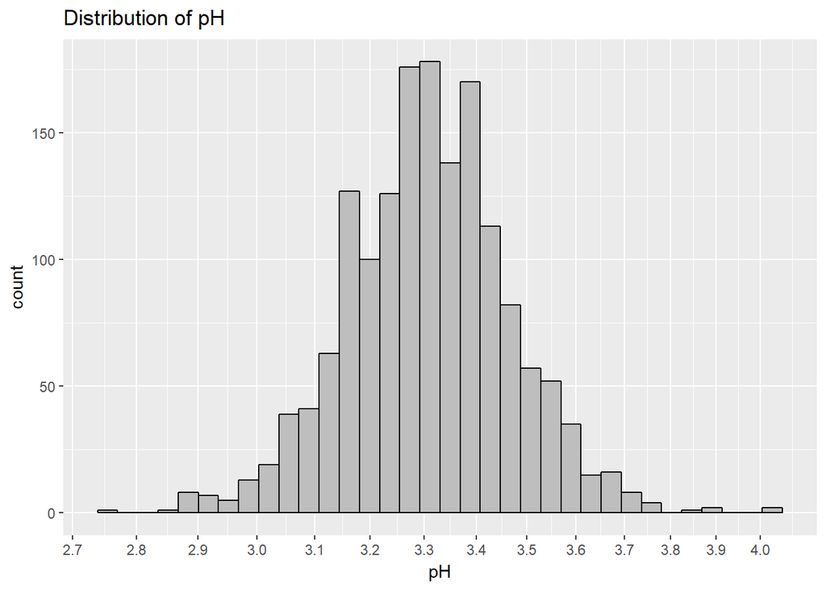

Observation: pH appears to be normally distributed, with the mean between 3.3 and 3.4.

#### 1.3. Acidity

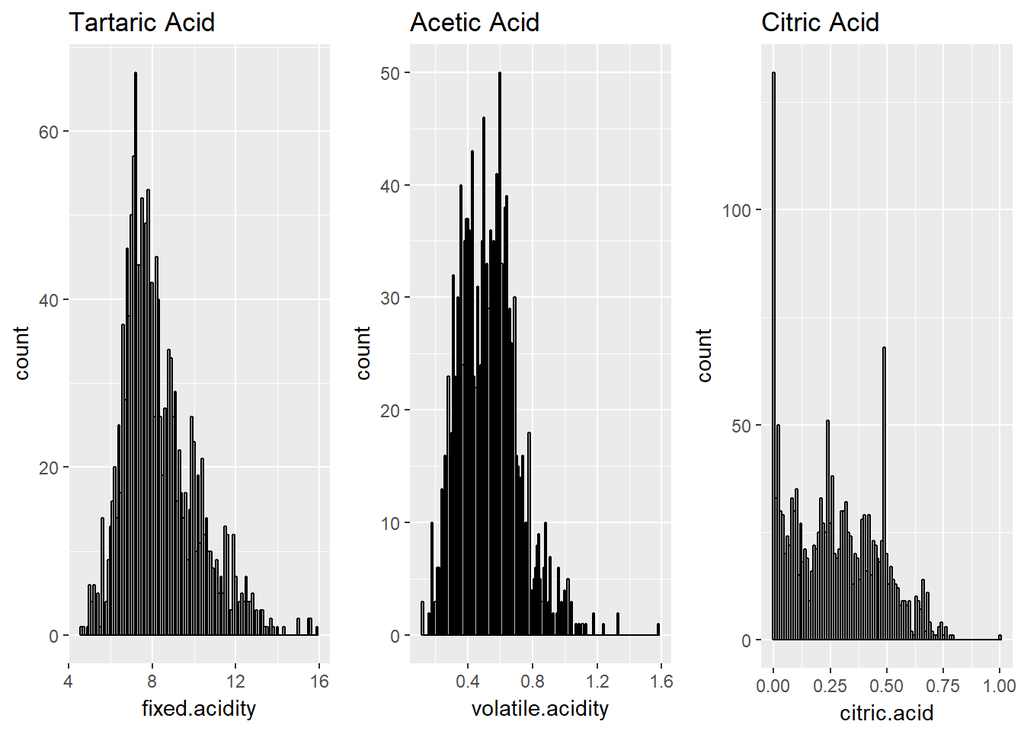

Observation: The distributions are skewed right due to the presence of outliers in all three charts. We can gain a better idea of the distributions by removing the outliers (I remove the top 5% of observations), and this gives me the revised charts below:

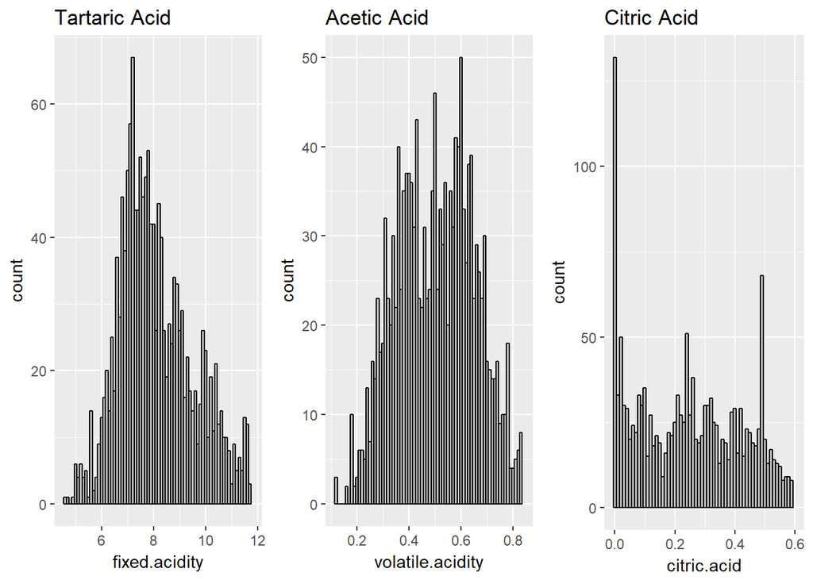

Observations: The distribution for tartaric Acid looks normal, while that for acetic acid looks bimodal normal. The distribution for citric acid is multimodal, but the overall shape looks more like a uniform distribution. Moreover, we observe that there is a large number of observations that are zero. Specifically, there are 132 wines without any citric acid.

Let us plot the citric.acid variable on it own:

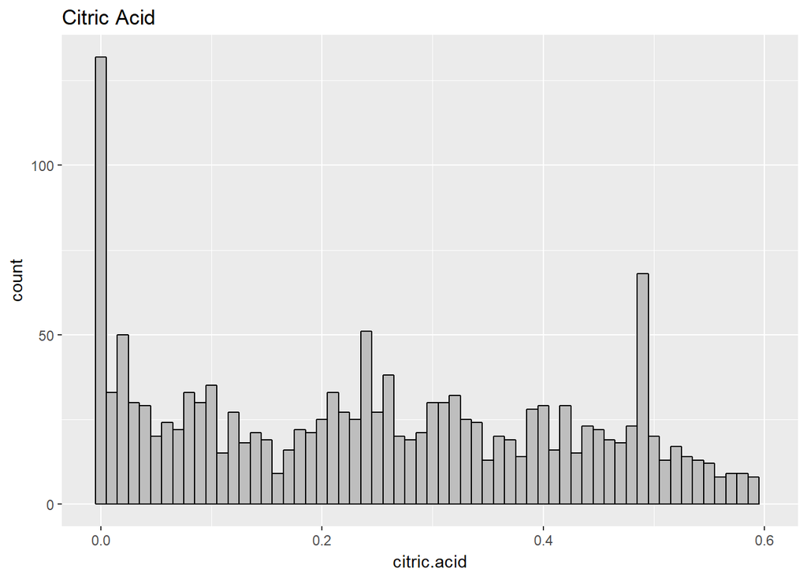

Observation: We see that besides zero, the other modes of the citric acid variable (at least 50 counts) are 0.02, 0.24 and 0.49.

I tried to transform the citric acid data using a log10 scale, but noting that the data is a multimodal distribution with the rest of the data seemingly uniformly distributed (as opposed to a skewed distribution that had a Gaussian shape), I was not expecting a normal distribution, and the chart below confirms my suspicion.

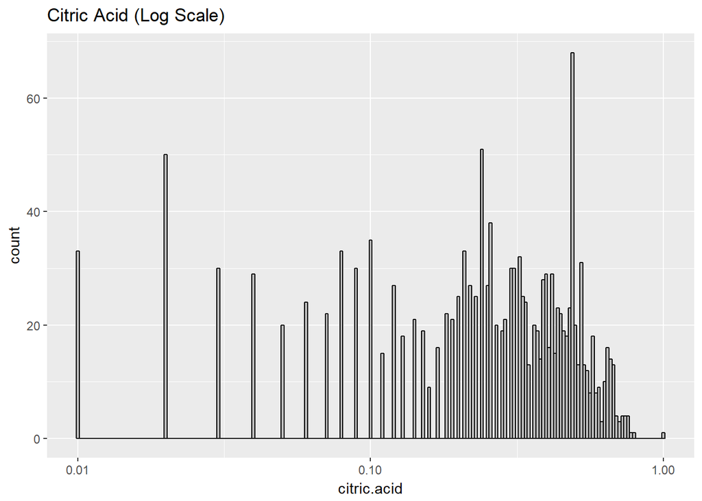

Finally, I conduct a log10 scale transformation for tartaric acid (fixed.acidity variable):

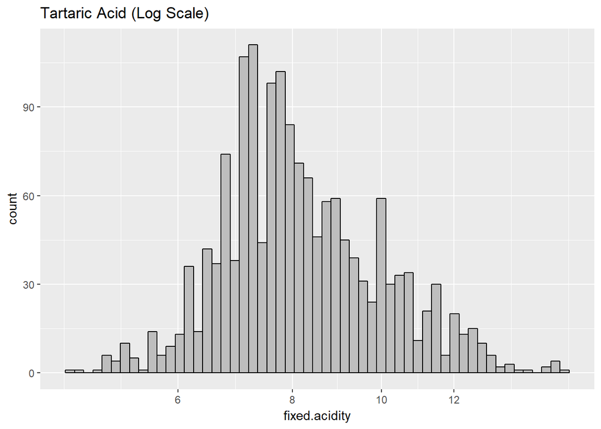

Observation: Similar to the discussion pertaining to alcohol content, the log transformation does not qualitatively change the shape of the tartatic acid distribution by much, given the limited range that the values take. However, the distribution can be said to be approximately normal, albeit with a slight right skew.

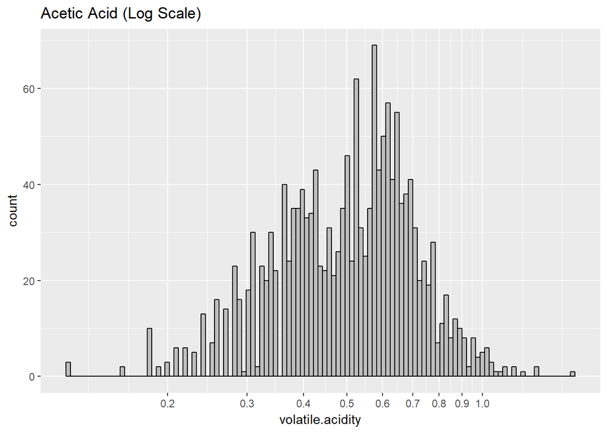

Observation: We see that the log scale has helped to reduce the long right tail of the acetic acid distribution without needing to remove outliers. The resultant distribution is approximately normal, however with multiple modes, occuring in the neighbourhood of 0.4, 0.55, and 0.6 values.

Finally, I created a new variable ‘compound acidity’ aggregating the various acidity variables. This will be analyzed in relation to pH later in this project. For now, I will analyze its properties in isolation, similar to what has been done to other variables in this section.

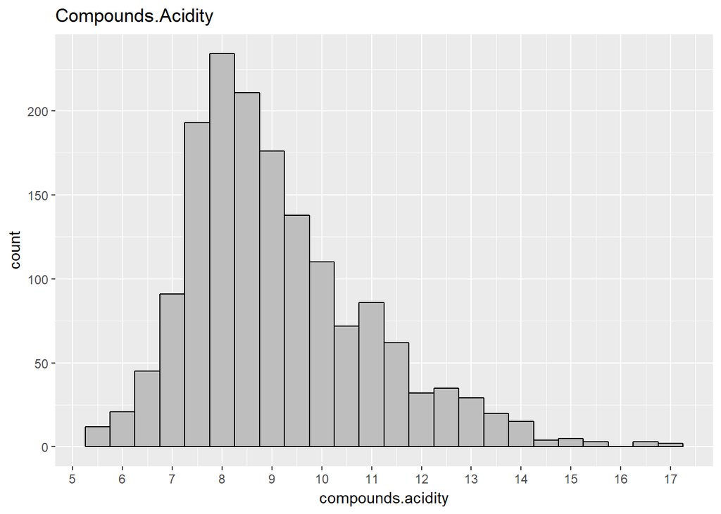

Observation: The distribution for the variable is skewed right, with the mode at around 8. I proceed to do a log scale transformation:

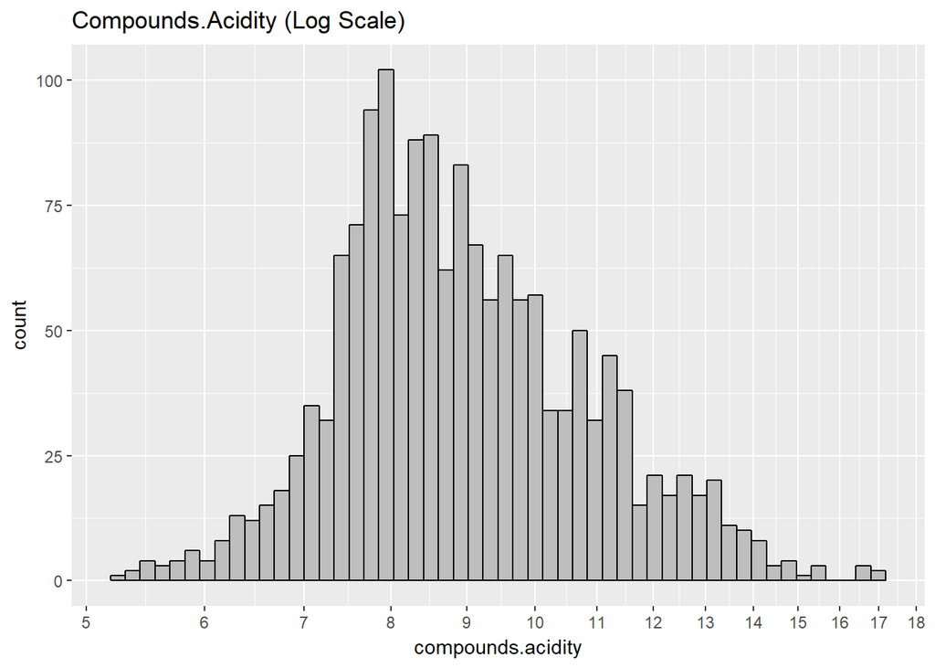

Observation: The transformed distribution looks a lot more normal.

Sum-up: Through data transformations, the fixed.acidity and volatile.acidity variables can be made normally distributed, which will enable us to perform standard inferential statistical calculations with them. However, the citric acid variable is not amenable to be modeled as normally distributed. This will not stop us from conducting visualizations with that variable, as I will do so in the later charts, but it will be trickier to conduct statistical inference using citric acid as an independent variable. Finally, we can sum the acidity variables together to give us a sense of the total amount of acid present in the wine, and this variable can be made to be approximately normally distributed.

#### 1.4. Sulphates and SO2

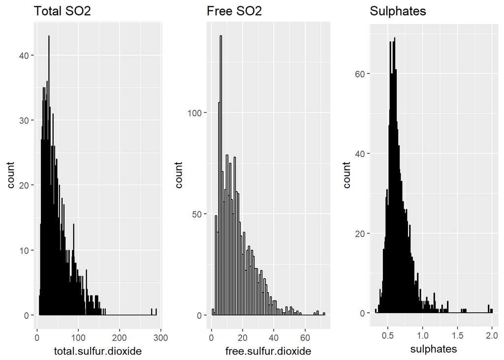

Observation: All three charts seem to be skewed right. We can choose to either exclude outliers, or use a log scale transformation. I do the former below:

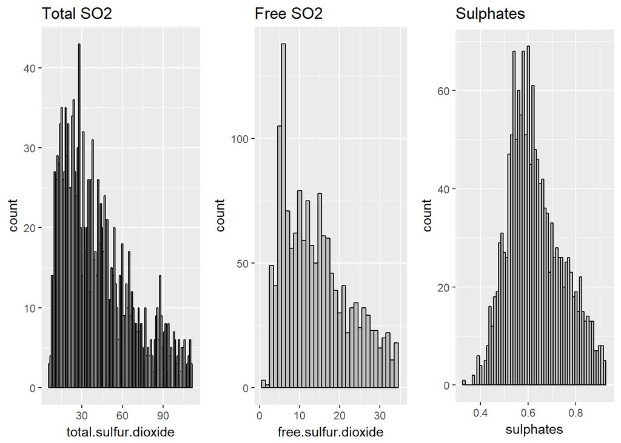

Observations: Removing the outliers give us a better sense of the distributions. Total SO2 and Free SO2 are skewed right, with the modes occurring at lower ends of the scale. Sulphates itself looks normally distributed.

However, plotting sulphates in isolation reveal that the data is also skewed right:

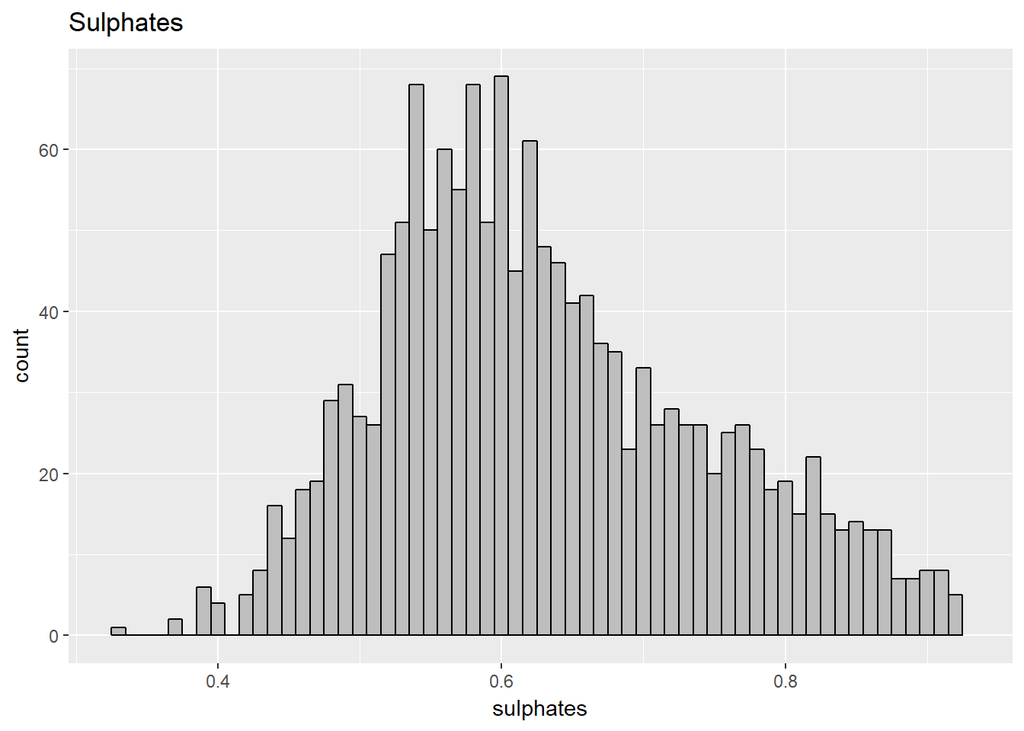

Hence, I conduct a log scale transformation for all three SO2 variables. First, I do so for sulphates. Besides conducting a log scale transformation, I remove outliers above the values of 1.2:

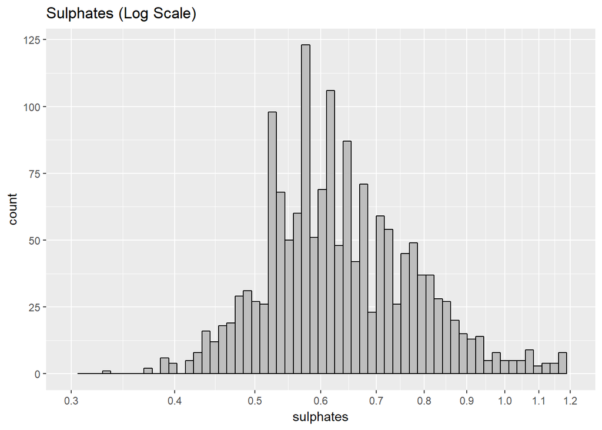

Observation: This distribution is approximately normal, which is what fitting a density curve would tell us. However, there are multiple modes occurring in the range of 0.5 - 0.6. Plotting a density curve instead visualizes this a bit more clearly:

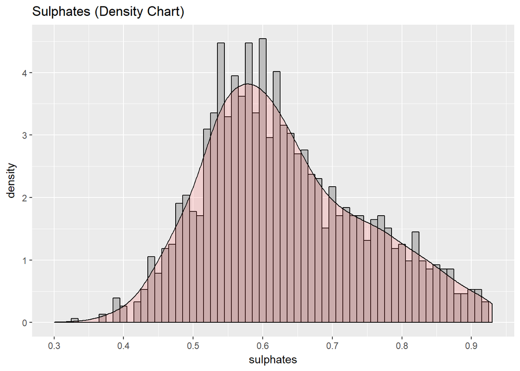

Observation: We have multiple modes occurring at 0.54, 0.58 and 0.6. Given that these values are close to each other (‘clustered’ between 0.5 and 0.6), I think it will be more accurate to classify the distribution of sulphates as having an approximately log-normal distribution, with the mean somewhere between 0.54 and 0.6, rather than call it a multimodal distribution.

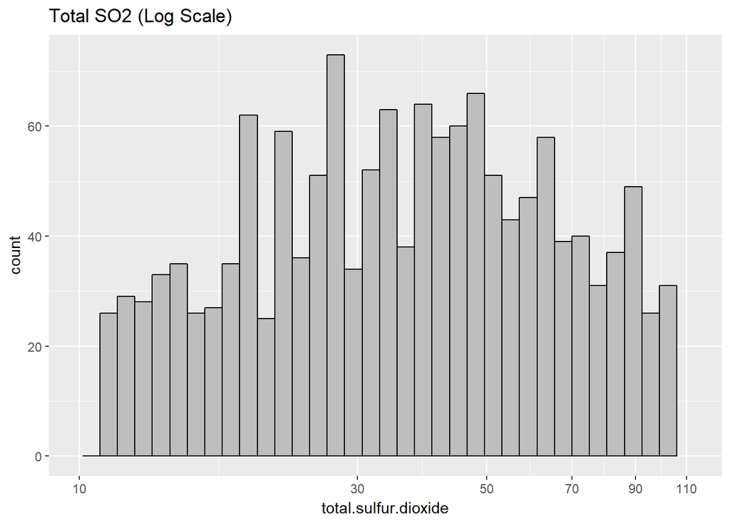

Observation: Using a log scale removes the right skew of the data. However, we see clearly from the chart that the data is not log-normal. The closest approximation to a standard distribution that I can think of is a uniform distribution, since the graph is ‘flattish’. Regardless, we cannot conduct standard statistical inference with normality assumptions using the total SO2 variable.

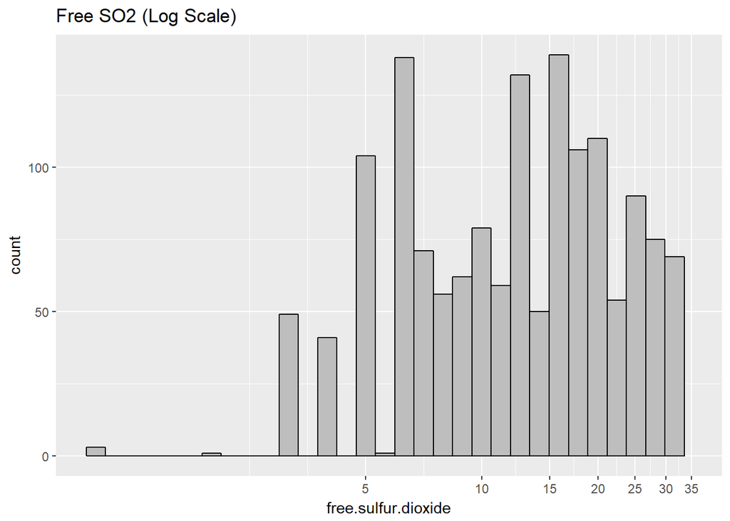

Observation: Similar to the previous chart, free SO2 is not log-normally distributed. It has multiple modes, at approximately values 5, 14, and 16.

Sum-up: With log scaling and outlier removal, sulphates can be made to be approximately log-normal distributed. However, this is not true for total SO2/free SO2 variables.

#### 1.5. ‘Compounds.Total’

I create a ‘compounds.total’ variable which sums the various chemical concentrations present in the wine, which will be used to analyze in relation to density and alcohol concentration later. Let us briefly examine its properties in isolation.

In the chart below, I plot the distribution of the compounds.total variable, removing its outliers.

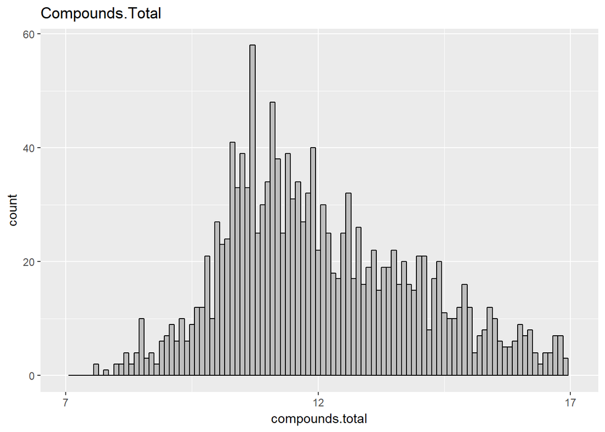

Observation: The shape looks approximately normal, but it has a relatively long and ‘fat’ right tail. I use log scaling and get the following:

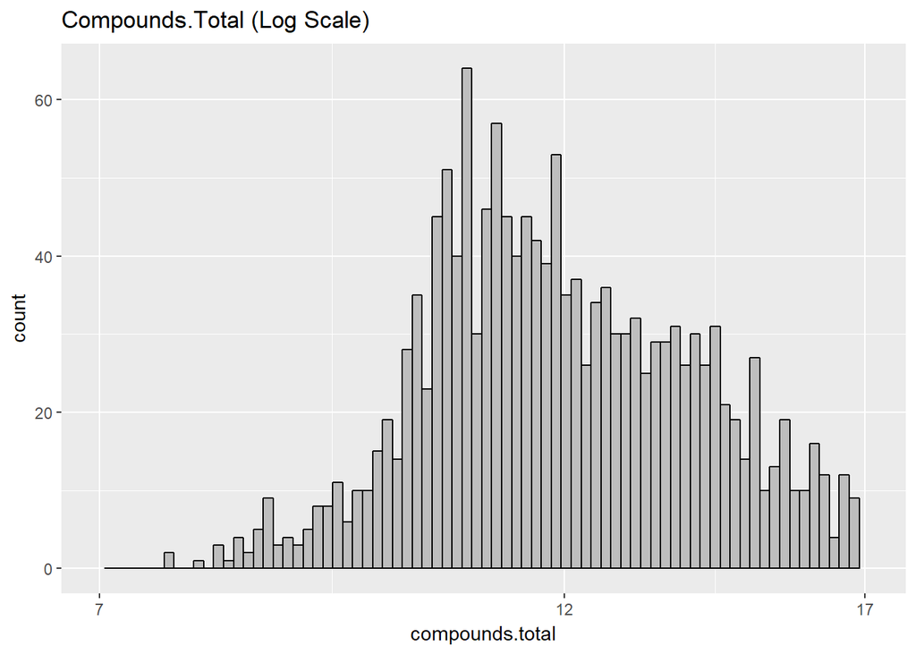

The right tail has been shortened somewhat, and the data is approximately long-normally distributed.

#### 1.6 Balance

Finally, we analyze the ‘balance’ variable, which is the ratio of acidic compounds (represented by the compounds.acidity variable) over residual sugar.

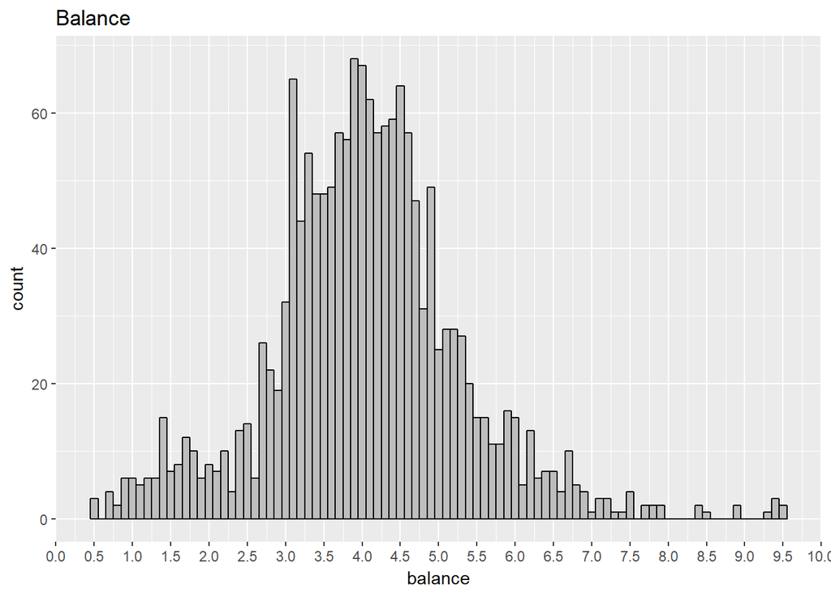

Observation: In this case, the distribution is looks to be approximately normal already, with the mode somewhere between 4 and 4.5.

### 2. Bivariate Plots - Wine Quality

Choice of Plot: Looking at the summary of the variables above in section 1, I noted that the quality variable was in a discrete numerical scale, while many of the chemical variables are in continuous numerical scales. These data features suggest that boxplots, with quality in the x-axis, and continuous variables in the y-axis, could be appropriate as preliminary bivariate plots to illustrate basic relationships between quality and other variables.

#### 2.1. Acidity and Quality

##### Fixed Acidity (Tartatic Acid)

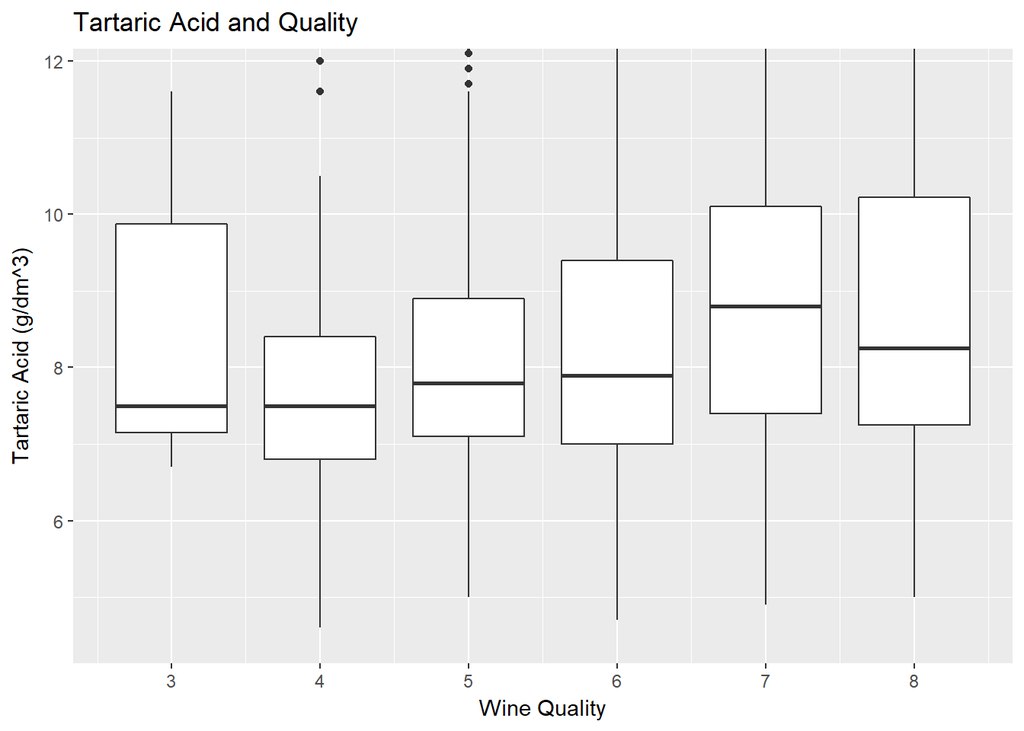

Observation: There is no clear trend between fixed acidity and quality here. Using the amount of ‘overlap’ between the boxplots as a first crude approximation of whether fixed acidity matters, the differences in fixed acidity between wines of different quality are not large, and hence do not (by themselves) account for much of the differences in quality.

##### Volatile Acidity (Acetic Acid)

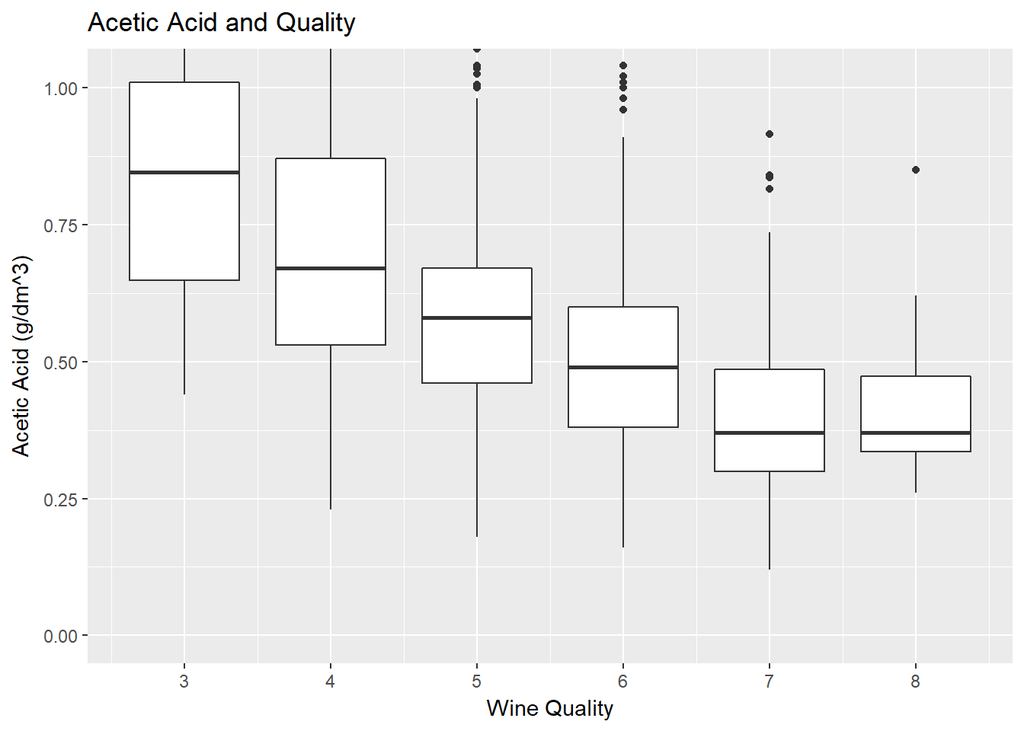

Observations:

##### Citric Acid

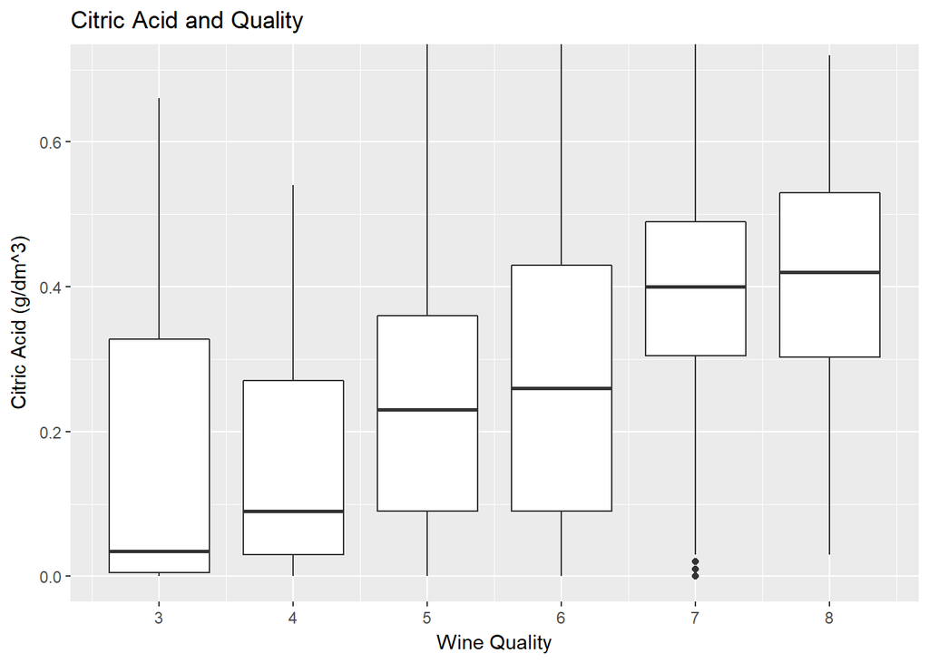

Observations:

#### 2.2. Sulfur Dioxide and Sulphites

##### Total Sulfur Dioxide

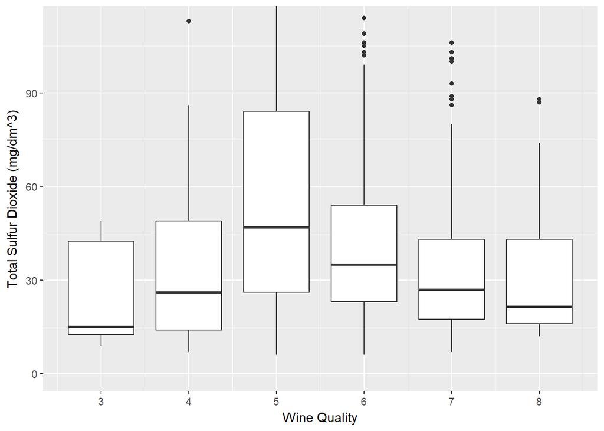

##### Free Sulfur Dioxide

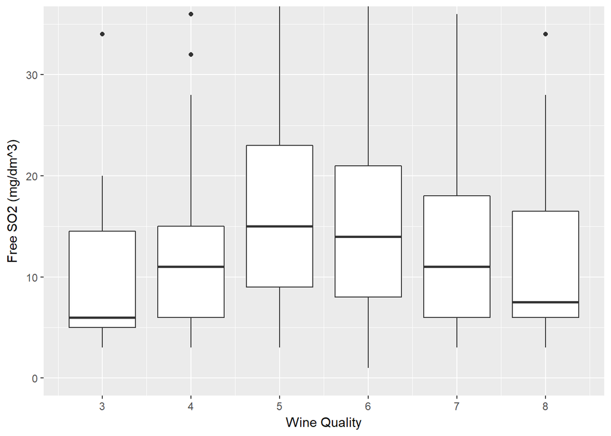

Observation: Unsurprisingly, given free SO2’s role as wine preservative, the qualitative patterns observed in this chart are similar to that of the boxplot with total SO2.

##### Sulphates

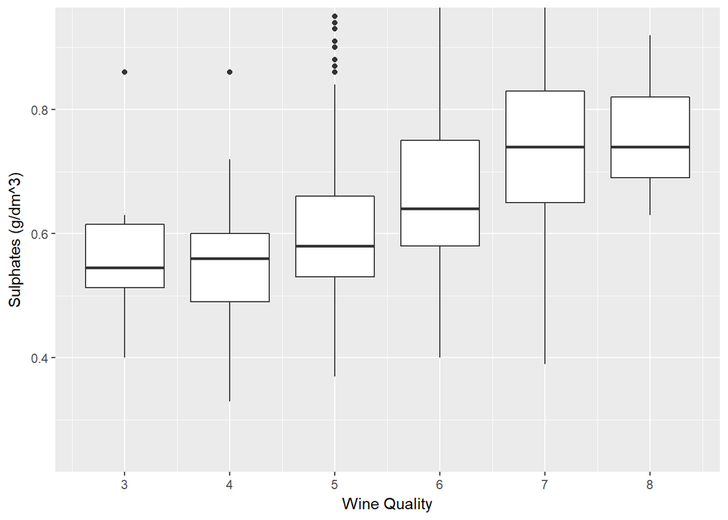

Observations:

1. We observe a upward trend here: Generally, the higher the quality of wine, the more sulphates it contains.
2. Looking at the red wine text file, we know that sulphates are a wine additive that acts as a antimicrobial and antioxidant. So it is not too surprising that wine above passable quality (score 5) have higher sulphite levels than those below passable quality.

#### 2.3. Sugar and Chlorides

##### Residual Sugar

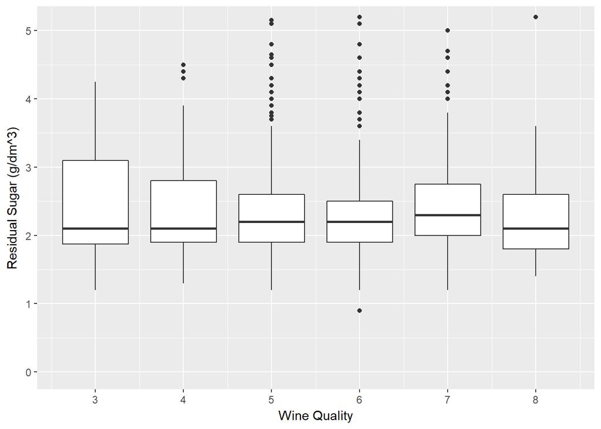

Observation: There are no significant differences in residual sugar levels across wine quality.

##### Chlorides

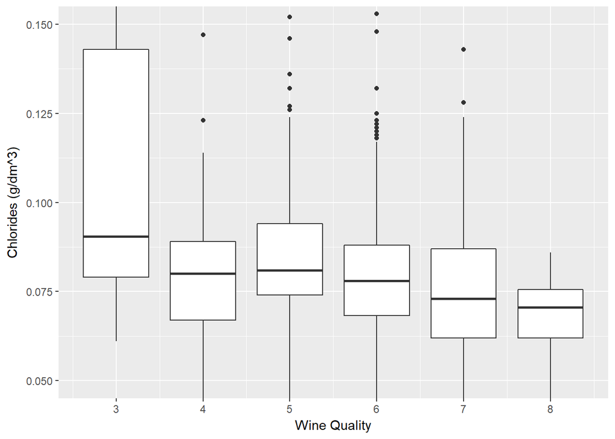

#### 2.4 Density, pH and Alcohol Content

##### Density

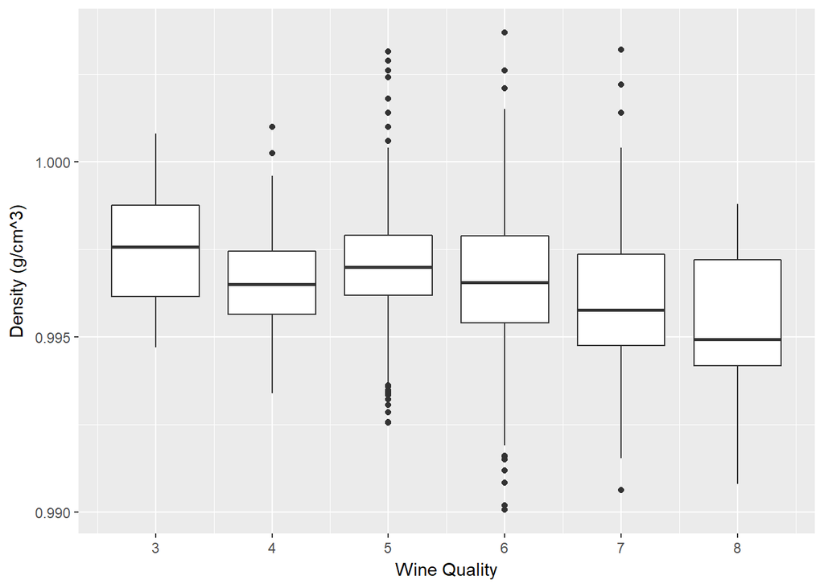

Observation: There is a slight downward trend in density as wine quality increases for wines of quality ratings 5 to 8.